# Hypoxia and mTOR Inhibition Reshape the Transcriptome of Normal and Triple Negative Breast Cancer Cells

A multifactor RNA seq differential expression analysis (GSE104193)

Freya Montgomerie

2026-09-11

# 1. Background and Motivation

Hypoxia is a defining feature of the tumour microenvironment. Cancer cells frequently alter their transcriptional and translational programmes to survive under low oxygen conditions. The mTOR pathway is a central regulator of protein synthesis and is closely linked to oxygen and nutrient sensing. This makes mTOR inhibitors, such as PP242, of interest both as research tools and as potential cancer therapeutics.

This project analyses a public RNA seq dataset (GSE104193), comparing a non malignant breast epithelial cell line (MCF10A) with a triple negative breast cancer cell line (MDA-MB-231). Cells were exposed to normoxia or hypoxia, with and without the mTORC1/2 inhibitor PP242, and both total and polysome bound mRNA were profiled. This gives a factorial design (2 cell lines x 2 oxygen levels x 2 drug conditions x 2 mRNA fractions, 2 biological replicates each, 32 samples total), which was used to ask:

1. How does hypoxia change gene expression, and does this differ between the normal and cancer cell lines?
2. Is hypoxia’s effect on transcription also seen proportionally in the polysome bound (translating) mRNA pool, or is there evidence of hypoxia specific translational control?

# 2. Data and Methods

## 2.1 Data retrieval

I retrieved the raw RSEM expected counts and sample metadata directly from GEO using the `GEOquery` package. Two supplementary count files were provided, split by cell line, which I merged into a single 60,554 gene by 32 sample count matrix. Sample identity across the two files could not be assumed from row or column order, so this was resolved using the explicit `barcode:ch1` metadata field instead. I checked the mapping was correct by confirming exact agreement between the metadata sample IDs and the count matrix column names before proceeding.

```r
gse <- getGEO("GSE104193", GSEMatrix = TRUE)
gse <- gse[[1]]
pheno <- pData(gse)

supp_dir <- "data/raw/GSE104193"
supp_files_expected <- file.path(supp_dir, c(
  "GSE104193_COUNTS_POLYSOME_01_new_pipeline.txt.gz",
  "GSE104193_COUNTS_POLYSOME_02_new_pipeline.txt.gz"
))

if (!all(file.exists(supp_files_expected))) {
  getGEOSuppFiles("GSE104193", baseDir = "data/raw")
} else {
  message("Supplementary files already present locally — skipping re-download.")
}

counts_01 <- read.delim(supp_files_expected[1],
                         header = TRUE, row.names = 1, check.names = FALSE)
counts_02 <- read.delim(supp_files_expected[2],
                         header = TRUE, row.names = 1, check.names = FALSE)
```

## 2.2 Sample metadata construction

```r
sample_info <- pheno %>%
  rownames_to_column("geo_accession_row") %>%
  transmute(
    gsm = geo_accession,
    barcode = `barcode:ch1`,
    cell_line = `cell line:ch1`,
    fraction = `fraction:ch1`,
    replicate = `replicate:ch1`,
    treatment_raw = `treatment:ch1`
  ) %>%
  separate(treatment_raw, into = c("oxygen", "drug"), sep = "\\+", fill = "right") %>%
  mutate(
    drug = ifelse(is.na(drug), "Control", drug),
    fraction = recode(fraction, "Total mRNA" = "Total", "Polysomal mRNA" = "Polysomal"),
    replicate = recode(replicate, "Biological replicate 1" = "Rep1", "Biological replicate 2" = "Rep2")
  )

counts_combined <- cbind(counts_01, counts_02)
barcode_to_gsm <- setNames(sample_info$gsm, sample_info$barcode)
colnames(counts_combined) <- barcode_to_gsm[colnames(counts_combined)]
counts_combined <- counts_combined[, sample_info$gsm]

stopifnot(all(colnames(counts_combined) == sample_info$gsm))

coldata <- sample_info
rownames(coldata) <- coldata$gsm
coldata$cell_line <- factor(coldata$cell_line, levels = c("MCF10A", "MDA-MB-231"))
coldata$fraction  <- factor(coldata$fraction, levels = c("Total", "Polysomal"))
coldata$oxygen    <- factor(coldata$oxygen, levels = c("Normoxia", "Hypoxia"))
coldata$drug      <- factor(coldata$drug, levels = c("Control", "PP242"))
coldata$replicate <- factor(coldata$replicate)

kable(head(coldata))
```

|  | gsm | barcode | cell_line | fraction | replicate | oxygen | drug |
| --- | --- | --- | --- | --- | --- | --- | --- |
| GSM2791560 | GSM2791560 | O097 | MCF10A | Total | Rep1 | Normoxia | Control |
| GSM2791561 | GSM2791561 | O098 | MCF10A | Total | Rep1 | Hypoxia | Control |
| GSM2791562 | GSM2791562 | O099 | MCF10A | Total | Rep1 | Normoxia | PP242 |
| GSM2791563 | GSM2791563 | O100 | MCF10A | Total | Rep1 | Hypoxia | PP242 |
| GSM2791564 | GSM2791564 | O101 | MCF10A | Polysomal | Rep1 | Normoxia | Control |
| GSM2791565 | GSM2791565 | O102 | MCF10A | Polysomal | Rep1 | Hypoxia | Control |

## 2.3 Differential expression model

Counts were rounded to integers, as required by DESeq2, because RSEM produces expected counts rather than integer counts. Genes with fewer than 10 reads in at least 4 samples were removed before modelling.

I used a multi-factor design:

```
~ cell_line + oxygen + drug + fraction + cell_line:oxygen + oxygen:fraction
```

I did not fit a fully saturated four way factorial model. With only 2 biological replicates per condition, an unconstrained model would leave very few residual degrees of freedom for reliable dispersion estimation. Instead, the interaction terms included were chosen based on the specific questions in Section 1. The `cell_line:oxygen` term tests whether the hypoxia response differs between the normal and cancer cell lines. The `oxygen:fraction` term tests whether hypoxia’s effect on transcription is also seen proportionally in the polysome bound (translating) mRNA pool.

```r
counts_int <- round(as.matrix(counts_combined))

dds <- DESeqDataSetFromMatrix(
  countData = counts_int,
  colData = coldata,
  design = ~ cell_line + oxygen + drug + fraction + cell_line:oxygen + oxygen:fraction
)
keep <- rowSums(counts(dds) >= 10) >= 4
dds <- dds[keep, ]
dds <- DESeq(dds)

nrow(dds)
```

```
## [1] 17910
```

```r
resultsNames(dds)
```

```
## [1] "Intercept"                         "cell_line_MDA.MB.231_vs_MCF10A"
## [3] "oxygen_Hypoxia_vs_Normoxia"        "drug_PP242_vs_Control"
## [5] "fraction_Polysomal_vs_Total"       "cell_lineMDA.MB.231.oxygenHypoxia"
## [7] "oxygenHypoxia.fractionPolysomal"
```

Filtering retained 17910 of the original 60554 genes for modelling. Effect sizes were shrunk using apeglm (Zhu, Ibrahim and Love, 2018) before ranking and visualisation.

# 3. Quality Control

## 3.1 Library sizes

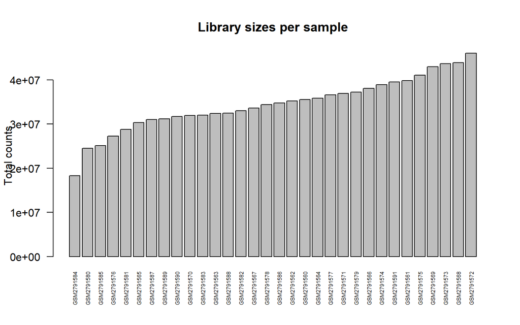

```r
library_sizes <- colSums(counts(dds))
barplot(sort(library_sizes), las = 2, cex.names = 0.5,
        main = "Library sizes per sample", ylab = "Total counts")
```

Library sizes ranged from 18.3M to 46M reads across the 32 samples. This was accounted for using DESeq2’s median of ratios size factor normalisation.

## 3.2 Sample structure (PCA)

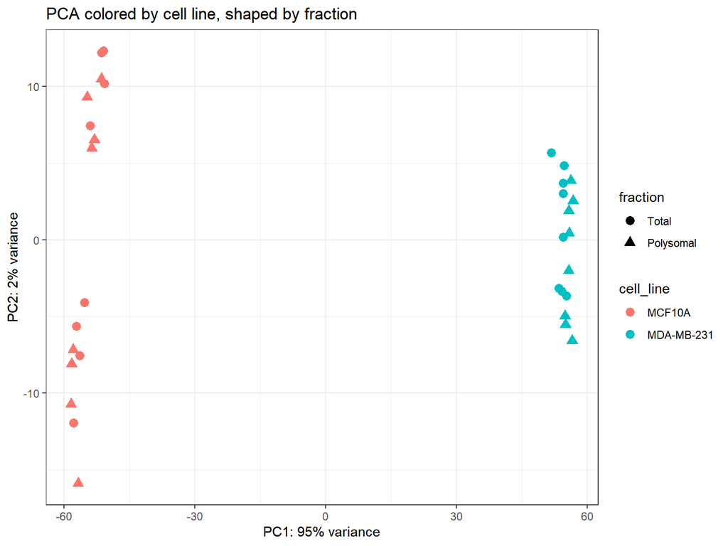

```r
vsd <- vst(dds, blind = TRUE)
pca_data <- plotPCA(vsd, intgroup = c("cell_line", "oxygen", "drug", "fraction"), returnData = TRUE)
percentVar <- round(100 * attr(pca_data, "percentVar"))

ggplot(pca_data, aes(x = PC1, y = PC2, color = cell_line, shape = fraction)) +
  geom_point(size = 3) +
  xlab(paste0("PC1: ", percentVar[1], "% variance")) +
  ylab(paste0("PC2: ", percentVar[2], "% variance")) +
  theme_bw() +
  labs(title = "PCA colored by cell line, shaped by fraction")
```

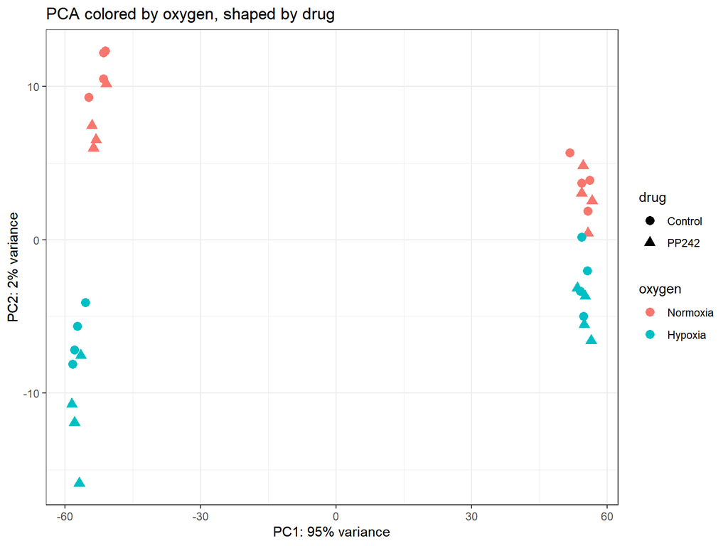

```r
ggplot(pca_data, aes(x = PC1, y = PC2, color = oxygen, shape = drug)) +
  geom_point(size = 3) +
  xlab(paste0("PC1: ", percentVar[1], "% variance")) +
  ylab(paste0("PC2: ", percentVar[2], "% variance")) +
  theme_bw() +
  labs(title = "PCA colored by oxygen, shaped by drug")
```

PC1 (95% of variance) separated samples by cell line. This is expected, as MCF10A (non malignant) and MDA-MB-231 (triple negative cancer) are very different cell types at the transcriptional level. PC2 (2% of variance) separated samples by oxygen level within both cell lines. Although this is a small proportion of the total variance, the separation was consistent across both cell lines, which suggests a real hypoxia signature. Neither drug nor mRNA fraction produced a visible separation on the top two PCs. This suggests these effects are smaller, and may be restricted to specific groups of genes rather than affecting the whole transcriptome.

## 3.3 Dispersion estimates

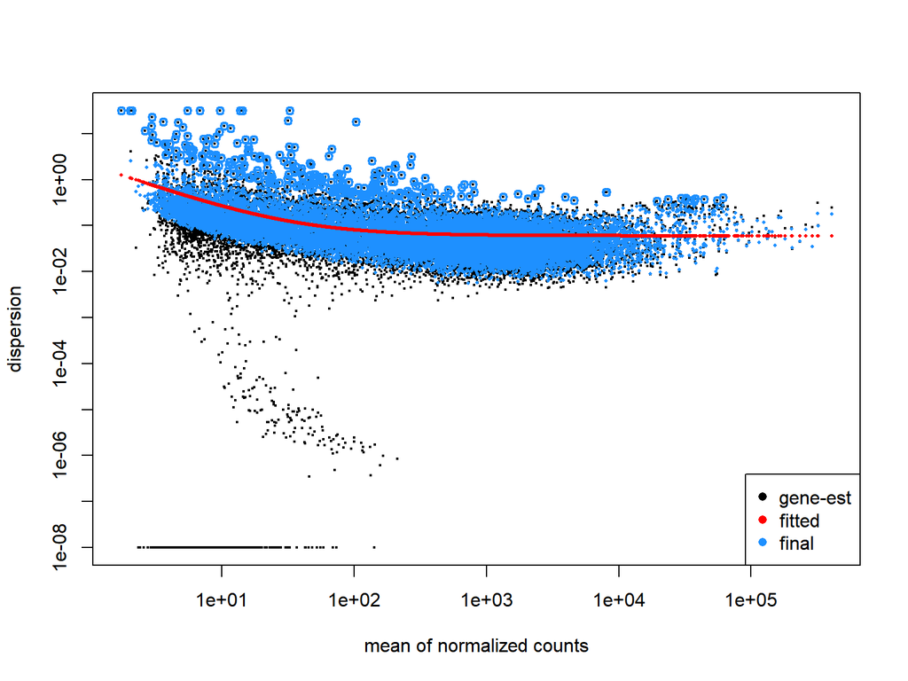

```r
plotDispEsts(dds)
```

Gene wise dispersion estimates shrank towards the fitted trend, as expected. A small number of genes showed unusually low dispersion estimates at low mean counts. This is a known artefact caused by rounding the non integer RSEM expected counts to integers, and is corrected by DESeq2’s shrinkage.

# 4. Results

## 4.1 Hypoxia response in normal (MCF10A) cells

```r
res_hypoxia_MCF10A <- results(dds, name = "oxygen_Hypoxia_vs_Normoxia")
res_hypoxia_MCF10A_shrunk <- lfcShrink(dds, coef = "oxygen_Hypoxia_vs_Normoxia", type = "apeglm")
summary(res_hypoxia_MCF10A)
```

```
##
## out of 17910 with nonzero total read count
## adjusted p-value < 0.1
## LFC > 0 (up)       : 2965, 17%
## LFC < 0 (down)     : 2406, 13%
## outliers [1]       : 0, 0%
## low counts [2]     : 0, 0%
## (mean count < 2)
## [1] see 'cooksCutoff' argument of ?results
## [2] see 'independentFiltering' argument of ?results
```

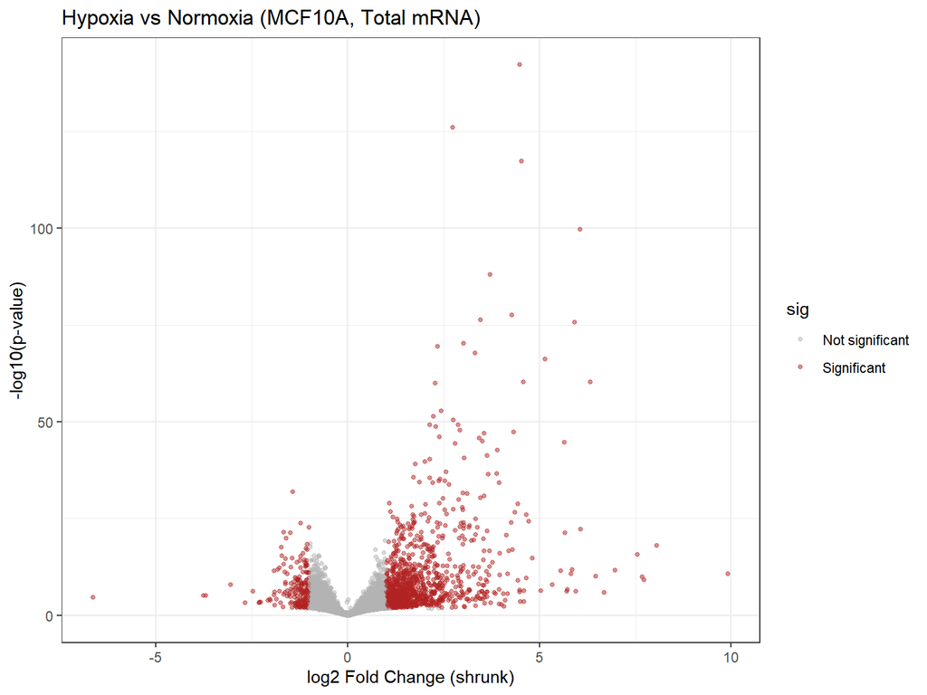

```r
gene_info <- data.frame(
  full_id = rownames(dds),
  ensembl_id = sapply(strsplit(rownames(dds), ","), `[`, 1),
  gene_symbol = sapply(strsplit(rownames(dds), ","), `[`, 2),
  biotype = sapply(strsplit(rownames(dds), ","), `[`, 3)
)

volcano_df <- as.data.frame(res_hypoxia_MCF10A_shrunk)
volcano_df$gene_symbol <- gene_info$gene_symbol[match(rownames(volcano_df), gene_info$full_id)]
volcano_df$sig <- ifelse(!is.na(volcano_df$padj) & volcano_df$padj < 0.05 & abs(volcano_df$log2FoldChange) > 1,
                          "Significant", "Not significant")

ggplot(volcano_df, aes(x = log2FoldChange, y = -log10(pvalue), color = sig)) +
  geom_point(alpha = 0.5, size = 1) +
  scale_color_manual(values = c("Significant" = "firebrick", "Not significant" = "grey70")) +
  theme_bw() +
  labs(title = "Hypoxia vs Normoxia (MCF10A, Total mRNA)",
       x = "log2 Fold Change (shrunk)", y = "-log10(p-value)")
```

```r
top_hypoxia_genes <- volcano_df %>%
  filter(!is.na(padj)) %>%
  arrange(padj) %>%
  dplyr::select(gene_symbol, log2FoldChange, padj) %>%
  head(20)

kable(top_hypoxia_genes, digits = 3)
```

|  | gene_symbol | log2FoldChange | padj |
| --- | --- | --- | --- |
| ENSG00000181458.10,TMEM45A,protein_coding | TMEM45A | 4.483 | 0 |
| ENSG00000111674.8,ENO2,protein_coding | ENO2 | 2.731 | 0 |
| ENSG00000147852.15,VLDLR,protein_coding | VLDLR | 4.535 | 0 |
| ENSG00000107159.12,CA9,protein_coding | CA9 | 6.060 | 0 |
| ENSG00000113083.12,LOX,protein_coding | LOX | 3.712 | 0 |
| ENSG00000061656.9,SPAG4,protein_coding | SPAG4 | 4.276 | 0 |
| ENSG00000074410.13,CA12,protein_coding | CA12 | 3.461 | 0 |
| ENSG00000129521.13,EGLN3,protein_coding | EGLN3 | 5.910 | 0 |
| ENSG00000170379.19,TCAF2,protein_coding | TCAF2 | 3.020 | 0 |
| ENSG00000104765.14,BNIP3L,protein_coding | BNIP3L | 2.352 | 0 |
| ENSG00000114268.11,PFKFB4,protein_coding | PFKFB4 | 3.314 | 0 |
| ENSG00000143847.15,PPFIA4,protein_coding | PPFIA4 | 5.145 | 0 |
| ENSG00000165507.8,C10orf10,protein_coding | C10orf10 | 6.333 | 0 |
| ENSG00000205129.8,C4orf47,protein_coding | C4orf47 | 4.580 | 0 |
| ENSG00000072682.18,P4HA2,protein_coding | P4HA2 | 2.286 | 0 |
| ENSG00000163710.7,PCOLCE2,protein_coding | PCOLCE2 | 2.434 | 0 |
| ENSG00000102144.13,PGK1,protein_coding | PGK1 | 2.239 | 0 |
| ENSG00000133874.1,RNF122,protein_coding | RNF122 | 2.758 | 0 |
| ENSG00000159167.11,STC1,protein_coding | STC1 | 2.880 | 0 |
| ENSG00000122884.12,P4HA1,protein_coding | P4HA1 | 2.146 | 0 |

Hypoxia caused widespread transcriptional changes in MCF10A cells. The genes with the strongest induction included known HIF target genes: CA9 and CA12 (pH regulation), EGLN3 (part of the oxygen sensing feedback loop), BNIP3L (hypoxia induced mitophagy), and the glycolysis genes PFKFB4 and PGK1. This shows the pipeline correctly identifies known hypoxia biology, which supports the validity of the wider analysis.

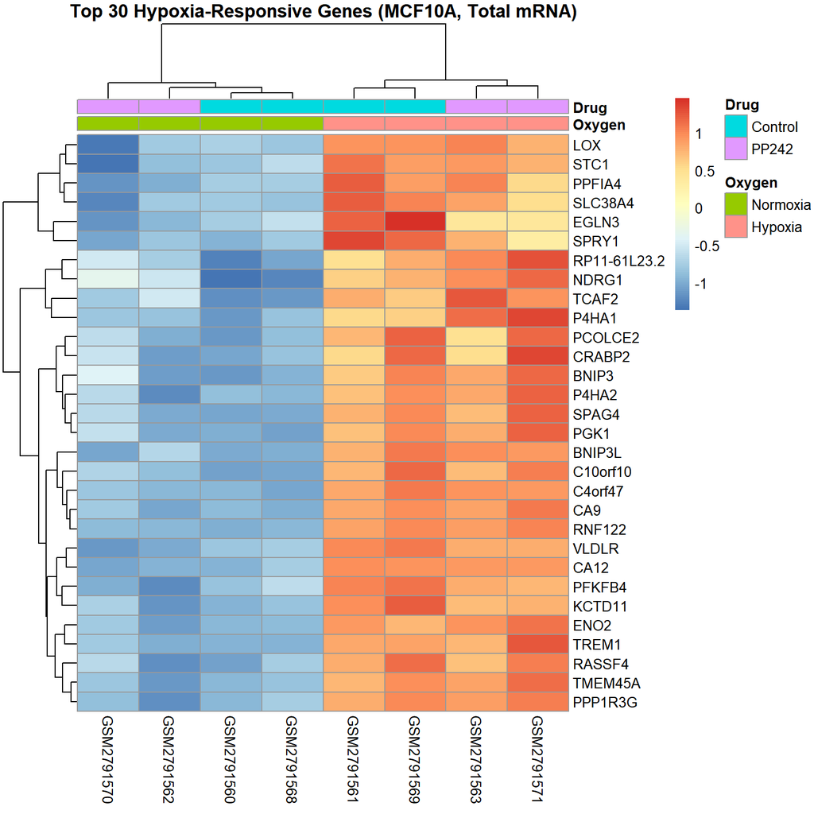

```r
top30 <- volcano_df %>% filter(!is.na(padj)) %>% arrange(padj) %>% head(30)
mcf10a_total_samples <- rownames(coldata)[coldata$cell_line == "MCF10A" & coldata$fraction == "Total"]
mat <- assay(vsd)[rownames(top30), mcf10a_total_samples]
mat_scaled <- t(scale(t(mat)))
rownames(mat_scaled) <- top30$gene_symbol

annotation_col <- data.frame(
  Oxygen = coldata[mcf10a_total_samples, "oxygen"],
  Drug = coldata[mcf10a_total_samples, "drug"]
)
rownames(annotation_col) <- mcf10a_total_samples

pheatmap(mat_scaled, annotation_col = annotation_col,
         main = "Top 30 Hypoxia-Responsive Genes (MCF10A, Total mRNA)")
```

## 4.2 Hypoxia response differs between normal and cancer cells

```r
res_interaction_cellline_oxygen <- results(dds, name = "cell_lineMDA.MB.231.oxygenHypoxia")
res_interaction_cellline_oxygen_shrunk <- lfcShrink(dds, coef = "cell_lineMDA.MB.231.oxygenHypoxia", type = "apeglm")
res_hypoxia_MDAMB231 <- results(dds, contrast = list(c("oxygen_Hypoxia_vs_Normoxia", "cell_lineMDA.MB.231.oxygenHypoxia")))

summary(res_interaction_cellline_oxygen)
```

```
##
## out of 17910 with nonzero total read count
## adjusted p-value < 0.1
## LFC > 0 (up)       : 1264, 7.1%
## LFC < 0 (down)     : 1669, 9.3%
## outliers [1]       : 0, 0%
## low counts [2]     : 0, 0%
## (mean count < 2)
## [1] see 'cooksCutoff' argument of ?results
## [2] see 'independentFiltering' argument of ?results
```

```r
summary(res_hypoxia_MDAMB231)
```

```
##
## out of 17910 with nonzero total read count
## adjusted p-value < 0.1
## LFC > 0 (up)       : 814, 4.5%
## LFC < 0 (down)     : 528, 2.9%
## outliers [1]       : 0, 0%
## low counts [2]     : 0, 0%
## (mean count < 2)
## [1] see 'cooksCutoff' argument of ?results
## [2] see 'independentFiltering' argument of ?results
```

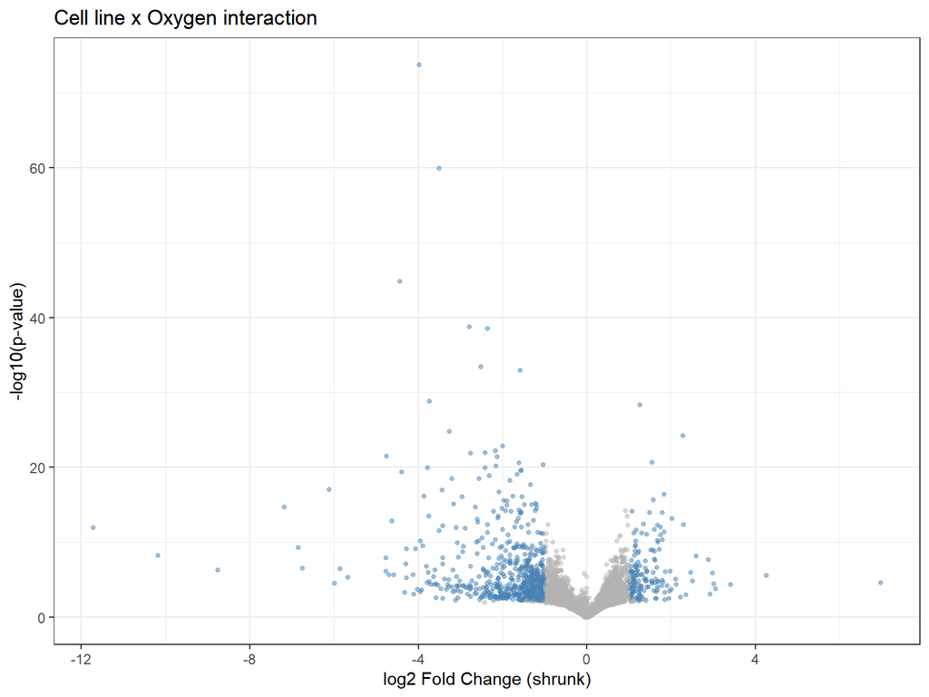

```r
interaction_df <- as.data.frame(res_interaction_cellline_oxygen_shrunk)
interaction_df$gene_symbol <- gene_info$gene_symbol[match(rownames(interaction_df), gene_info$full_id)]

ggplot(interaction_df, aes(x = log2FoldChange, y = -log10(pvalue),
                            color = !is.na(padj) & padj < 0.05 & abs(log2FoldChange) > 1)) +
  geom_point(alpha = 0.5, size = 1) +
  scale_color_manual(values = c("TRUE" = "steelblue", "FALSE" = "grey70"), guide = "none") +
  theme_bw() +
  labs(title = "Cell line x Oxygen interaction",
       x = "log2 Fold Change (shrunk)", y = "-log10(p-value)")
```

```r
top_interaction_genes <- interaction_df %>%
  filter(!is.na(padj)) %>%
  arrange(padj) %>%
  dplyr::select(gene_symbol, log2FoldChange, padj) %>%
  head(20)

mdamb231_df <- as.data.frame(res_hypoxia_MDAMB231)
mdamb231_df$gene_symbol <- gene_info$gene_symbol[match(rownames(mdamb231_df), gene_info$full_id)]

comparison_table <- top_interaction_genes %>%
  dplyr::select(gene_symbol, interaction_LFC = log2FoldChange, interaction_padj = padj) %>%
  left_join(volcano_df %>% dplyr::select(gene_symbol, MCF10A_hypoxia_LFC = log2FoldChange), by = "gene_symbol") %>%
  left_join(mdamb231_df %>% dplyr::select(gene_symbol, MDAMB231_hypoxia_LFC = log2FoldChange), by = "gene_symbol")

kable(comparison_table, digits = 3)
```

| gene_symbol | interaction_LFC | interaction_padj | MCF10A_hypoxia_LFC | MDAMB231_hypoxia_LFC |
| --- | --- | --- | --- | --- |
| CA12 | -3.984 | 0 | 3.461 | -0.528 |
| VLDLR | -3.510 | 0 | 4.535 | 1.004 |
| SPRY1 | -4.438 | 0 | 4.325 | -0.116 |
| SLC37A2 | -2.793 | 0 | 2.382 | -0.414 |
| PCOLCE2 | -2.361 | 0 | 2.434 | 0.066 |
| PLXNB3 | -2.517 | 0 | 2.225 | -0.295 |
| ENO2 | -1.574 | 0 | 2.731 | 1.146 |
| EGLN3 | -3.733 | 0 | 5.910 | 2.175 |
| RAB3IP | 1.264 | 0 | -1.011 | 0.260 |
| VWA1 | -3.268 | 0 | 3.665 | 0.378 |
| TINAGL1 | 2.286 | 0 | -1.727 | 0.558 |
| TMEM45A | -1.991 | 0 | 4.483 | 2.465 |
| STC1 | -2.168 | 0 | 2.880 | 0.693 |
| TIMP3 | -2.412 | 0 | 2.636 | 0.208 |
| PHEX | -2.755 | 0 | 1.921 | -0.828 |
| ANKFN1 | -4.752 | 0 | 4.659 | -0.122 |
| SLC38A4 | -2.129 | 0 | 2.800 | 0.651 |
| HSPH1 | 1.543 | 0 | -0.707 | 0.833 |
| POLM | -1.615 | 0 | 1.351 | -0.271 |
| PARP8 | -1.029 | 0 | 1.088 | 0.050 |

The hypoxia response was significantly reduced in MDA-MB-231 compared with MCF10A. This is consistent with reports that triple negative breast cancer lines can already show a partially hypoxic phenotype under normoxic conditions, meaning there is less room for further induction.

The reduction was not the same for every gene. CA12, SPRY1 and ANKFN1 showed an almost complete loss of hypoxia induction in MDA-MB-231, while EGLN3 (PHD3) remained significantly induced in both cell lines, although more weakly in MDA-MB-231. This suggests the reduced response may be specific to downstream target genes, while the oxygen sensing machinery itself remains at least partly functional.

## 4.3 Hypoxia’s transcriptional effect and the translating mRNA pool

```r
res_interaction_oxygen_fraction <- results(dds, name = "oxygenHypoxia.fractionPolysomal")
summary(res_interaction_oxygen_fraction)
```

```
##
## out of 17910 with nonzero total read count
## adjusted p-value < 0.1
## LFC > 0 (up)       : 0, 0%
## LFC < 0 (down)     : 0, 0%
## outliers [1]       : 0, 0%
## low counts [2]     : 0, 0%
## (mean count < 2)
## [1] see 'cooksCutoff' argument of ?results
## [2] see 'independentFiltering' argument of ?results
```

Limitation: with only 2 biological replicates per condition, this analysis does not have enough power to detect smaller or gene specific interaction effects. This result should be read as ruling out a large, genome wide effect, rather than ruling out translational regulation of individual transcripts.

## 4.4 Pathway-level validation (GSEA)

```r
gsea_input <- volcano_df %>%
  filter(!is.na(gene_symbol), !is.na(log2FoldChange)) %>%
  distinct(gene_symbol, .keep_all = TRUE)

gene_map <- bitr(gsea_input$gene_symbol, fromType = "SYMBOL", toType = "ENTREZID", OrgDb = org.Hs.eg.db)

gsea_input <- gsea_input %>%
  inner_join(gene_map, by = c("gene_symbol" = "SYMBOL")) %>%
  distinct(ENTREZID, .keep_all = TRUE)

ranked_genes <- gsea_input$log2FoldChange
names(ranked_genes) <- gsea_input$ENTREZID
ranked_genes <- sort(ranked_genes, decreasing = TRUE)

hallmark_sets <- msigdbr(species = "Homo sapiens", category = "H") %>%
  dplyr::select(gs_name, entrez_gene)

set.seed(42)
gsea_result <- GSEA(geneList = ranked_genes, TERM2GENE = hallmark_sets, pvalueCutoff = 0.05, eps = 0)

gsea_df <- as.data.frame(gsea_result) %>% arrange(desc(NES))
kable(gsea_df[, c("ID", "NES", "pvalue", "p.adjust")], digits = 3, row.names = FALSE)
```

| ID | NES | pvalue | p.adjust |
| --- | --- | --- | --- |
| HALLMARK_HYPOXIA | 2.456 | 0.000 | 0.000 |
| HALLMARK_GLYCOLYSIS | 2.055 | 0.000 | 0.000 |
| HALLMARK_EPITHELIAL_MESENCHYMAL_TRANSITION | 1.965 | 0.000 | 0.000 |
| HALLMARK_INFLAMMATORY_RESPONSE | 1.766 | 0.000 | 0.000 |
| HALLMARK_TNFA_SIGNALING_VIA_NFKB | 1.749 | 0.000 | 0.000 |
| HALLMARK_KRAS_SIGNALING_UP | 1.730 | 0.000 | 0.000 |
| HALLMARK_COAGULATION | 1.597 | 0.003 | 0.010 |
| HALLMARK_MYOGENESIS | 1.569 | 0.002 | 0.008 |
| HALLMARK_APICAL_JUNCTION | 1.544 | 0.001 | 0.004 |
| HALLMARK_IL2_STAT5_SIGNALING | 1.534 | 0.001 | 0.005 |
| HALLMARK_UV_RESPONSE_DN | 1.517 | 0.006 | 0.015 |
| HALLMARK_ESTROGEN_RESPONSE_EARLY | 1.462 | 0.005 | 0.013 |
| HALLMARK_P53_PATHWAY | 1.408 | 0.009 | 0.023 |
| HALLMARK_APOPTOSIS | 1.395 | 0.019 | 0.044 |
| HALLMARK_SPERMATOGENESIS | -1.691 | 0.001 | 0.003 |
| HALLMARK_DNA_REPAIR | -1.807 | 0.000 | 0.000 |
| HALLMARK_OXIDATIVE_PHOSPHORYLATION | -1.925 | 0.000 | 0.000 |
| HALLMARK_MYC_TARGETS_V2 | -2.491 | 0.000 | 0.000 |
| HALLMARK_G2M_CHECKPOINT | -2.704 | 0.000 | 0.000 |
| HALLMARK_MYC_TARGETS_V1 | -2.866 | 0.000 | 0.000 |
| HALLMARK_E2F_TARGETS | -3.157 | 0.000 | 0.000 |

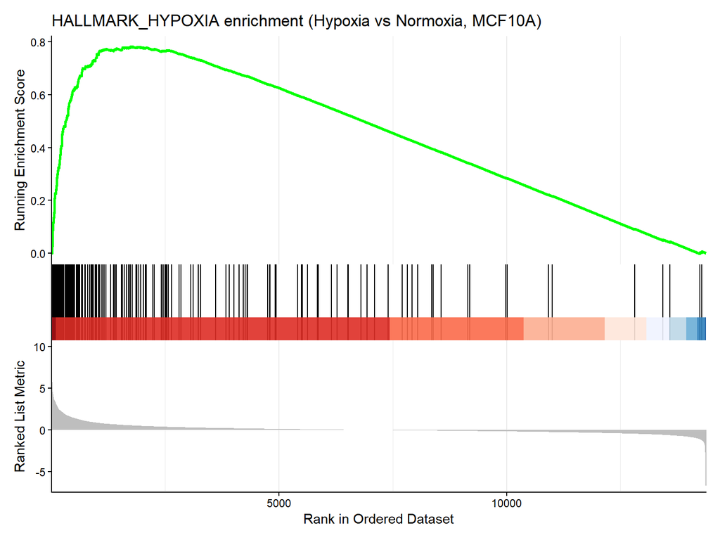

```r
gseaplot2(gsea_result, geneSetID = "HALLMARK_HYPOXIA",
          title = "HALLMARK_HYPOXIA enrichment (Hypoxia vs Normoxia, MCF10A)")
```

The wider results also formed a consistent pattern: HALLMARK_GLYCOLYSIS was upregulated alongside hypoxia. This reflects the shift towards glycolytic metabolism that occurs under low oxygen conditions. HALLMARK_OXIDATIVE_PHOSPHORYLATION was downregulated, which fits with this shift, as cells rely less on oxidative phosphorylation when oxygen is limited. Pathways linked to cell proliferation (HALLMARK_E2F_TARGETS, HALLMARK_G2M_CHECKPOINT, HALLMARK_MYC_TARGETS_V1/V2) were also strongly suppressed. This fits with the known hypoxia induced slowdown in cell cycle progression.

# 5. Discussion and Limitations

The aim of this analysis was to characterise the transcriptional response to hypoxia in a non malignant breast cell line, and to determine whether this response differs in a triple negative cancer cell line, or between total and polysome bound mRNA.

The results show a clear hypoxia signature in MCF10A cells. This is supported at multiple levels: individual genes matched known HIF targets, the pathway level GSEA result was strongly significant, and the PCA and heatmap both showed clean separation by oxygen condition. MDA-MB-231 cells showed a much weaker version of this response, and this reduction appeared to affect downstream effector genes more than the oxygen sensing machinery itself.

A key strength of this analysis was the multi factor design, which made it possible to test several biological questions from a single model rather than running separate pairwise comparisons. This is a more statistically defensible approach given the limited number of replicates available.

Several limitations should be considered:

- Replication: only 2 biological replicates were available per condition, which limits statistical power, particularly for interaction terms. The null oxygen:fraction result should not be taken as proof that no translational regulation occurs, only that a large effect was not detected.
- RSEM expected counts: rounding non integer expected counts to integers introduced minor artefacts in the dispersion estimates at low counts. These were corrected by DESeq2’s shrinkage step.
- PP242 (drug) effect: the transcriptional effect of the mTOR inhibitor was comparatively small in this dataset and was not the focus of the main analysis. A more targeted analysis, for example restricted to known mTOR sensitive transcripts or the translational efficiency ratio, could investigate this further.

Overall, this analysis shows that a multi factor RNA seq design can be used to characterise a known biological response (hypoxia) while also testing more specific questions about how that response differs between cell types and mRNA fractions, within a single reproducible pipeline.

# 6. References

- Korotkevich, G., Sukhov, V., Sergushichev, A. (2019) ‘Fast gene set enrichment analysis’. bioRxiv. doi:10.1101/060012
- Xu, S., Hu, E., Cai, Y., Xie, Z., Luo, X., Zhan, L., Tang, W., Wang, Q., Liu, B., Wang, R., Xie, W., Wu, T., Xie, L., Yu, G. (2024) ‘Using clusterProfiler to characterize multiomics data’. Nature Protocols, 19(11), pp.3292-3320. Doi: 10.1038/s41596-024-01020-z
- Zhu, A., Ibrahim, J.G., Love, M.I. (2018) ‘Heavy-tailed prior distributions for sequence count data: removing the noise and preserving large differences’. Bioinformatics, 35(12), pp.2084-2092. Doi:10.1093/bioinformatics/bty895
- Love, M.I., Huber, W. & Anders, S. (2014).’Moderated estimation of fold change and dispersion for RNA-seq data with DESeq2’. Genome Biology, 15(550). doi:10.1186/s13059-014-0550-8
- Original dataset: GSE104193: Sesé, M., Fuentes, P., Esteve-Codina, A., Béjar, E., McGrail, K., Thomas, G., Aasen, T., & Ramón Y Cajal, S. (2017). ‘Hypoxia-mediated translational activation of ITGB3 in breast cancer cells enhances TGF-β signaling and malignant features in vitro and in vivo’. Oncotarget, 8(70), PP.114856–114876.DOI:10.18632/oncotarget.23145